# Dynamic Data @ useR

# NHANES in Intro Stats

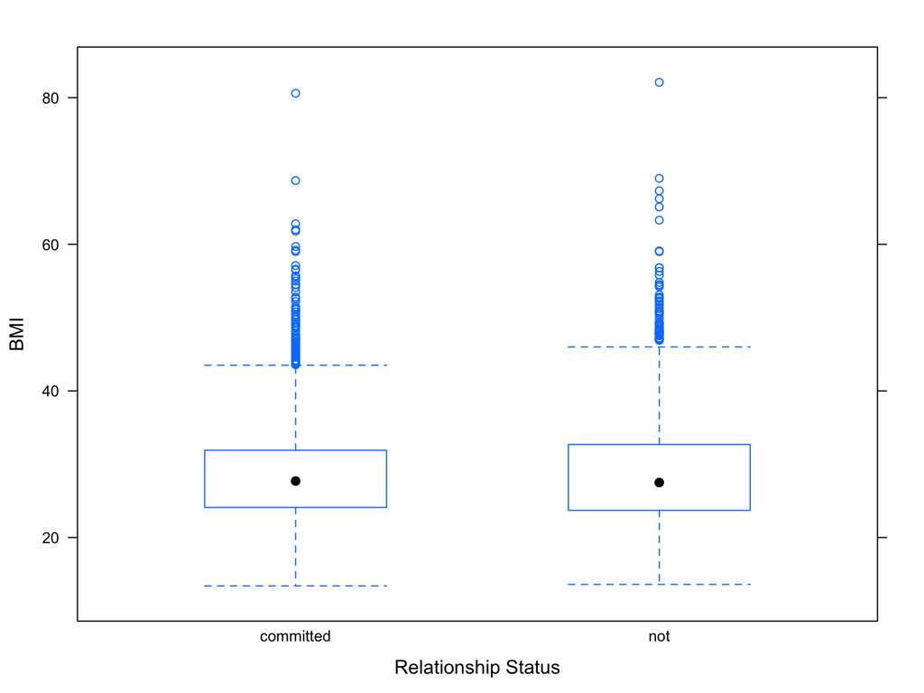

```r
Adults = NHANES.comb %>%
  filter(ridageyr >=18, bmxbmi>1) %>%
  filter(dmdmartl>0 & dmdmartl < 10) %>%
  mutate(rel=ifelse(dmdmartl==6|dmdmartl==1, "committed", "not")) %>%
  mutate(bmi=bmxbmi)

bwplot(bmi ~ rel, data=Adults, xlab="Relationship Status", ylab="BMI")
```

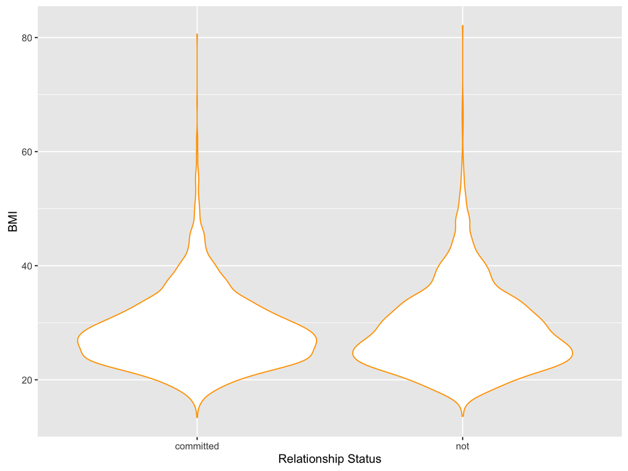

```r
ggplot(Adults, aes(rel, bmi))+ geom_violin(color="orange")+
  xlab("Relationship Status") + ylab("BMI")
```

```r
dim(Adults)
```

```
## [1] 5233   76
```

```r
t.test(bmi ~ rel, data=Adults)
```

```
##
##  Welch Two Sample t-test
##
## data:  bmi by rel
## t = -1.2218, df = 4576.5, p-value = 0.2219
## alternative hypothesis: true difference in means is not equal to 0
## 95 percent confidence interval:
##  -0.6209040  0.1441332
## sample estimates:
## mean in group committed       mean in group not
##                28.66960                28.90799
```

# NHANES beyond Intro Stats

In a linear models or computational statistics class, smooth curves might be a topic of discussion:

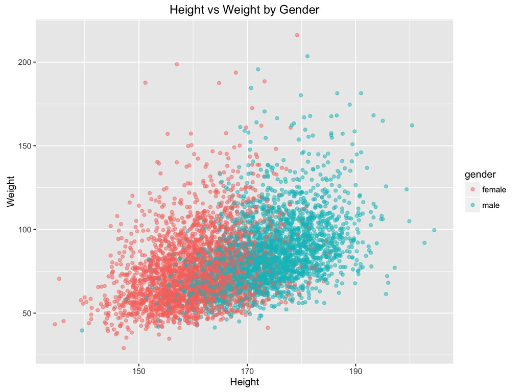

```r
ggplot(Adults, aes(x=bmxht, y=bmxwt, group=gender, color=gender)) + geom_point(alpha=.5)+
  xlab("Height") + ylab("Weight") + ggtitle("Height vs Weight by Gender")
```

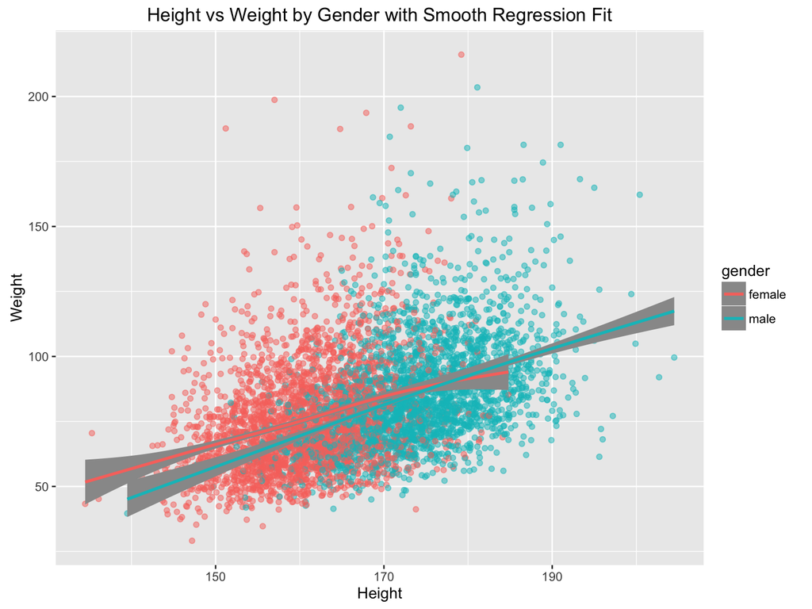

```r
ggplot(Adults, aes(x=bmxht, y=bmxwt, group=gender, color=gender)) +
  xlab("Height") + ylab("Weight") + geom_point(alpha=.5)+
  stat_smooth(alpha=1)+
  ggtitle("Height vs Weight by Gender with Smooth Regression Fit")
```

# Manuscript

- Format:
  - Example (description, documentation, references)
  - Using dynamic data in an introductory classroom
  - Thinking outside the box
- Full R Markdown files for downloading: https://github.com/hardin47/DynamicData
- Manuscript on arXiv: http://arxiv.org/abs/1603.04912

# Full Examples

- College Scorecard
- NHANES (National Health and Nutrition Examination Survey)
- Wikipedia (scraping XML / HTML)
- Gapminder (Literacy Rates, using **tidyr**’s **gather** function)
- NOAA weather data from buoys

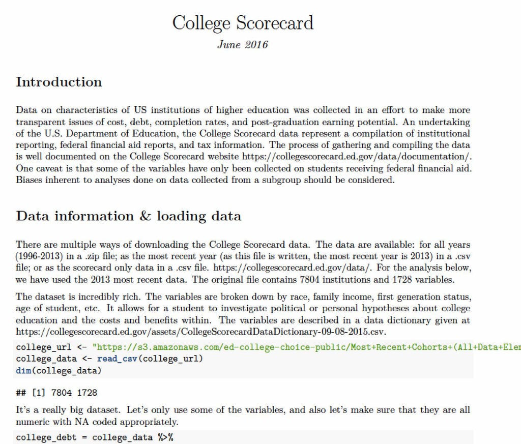

# Additional Examples

- Baseball Data (Jim Albert)
- Cherry Blossom Ten Mile Run (Kaplan, in Nolan & Temple Lang, 2015)
- Fatal Accidents & US Census Data (Laura Kapitula)
- Climate Data
- Iowa Liquor Sales
- Medicare Inpatient Charges

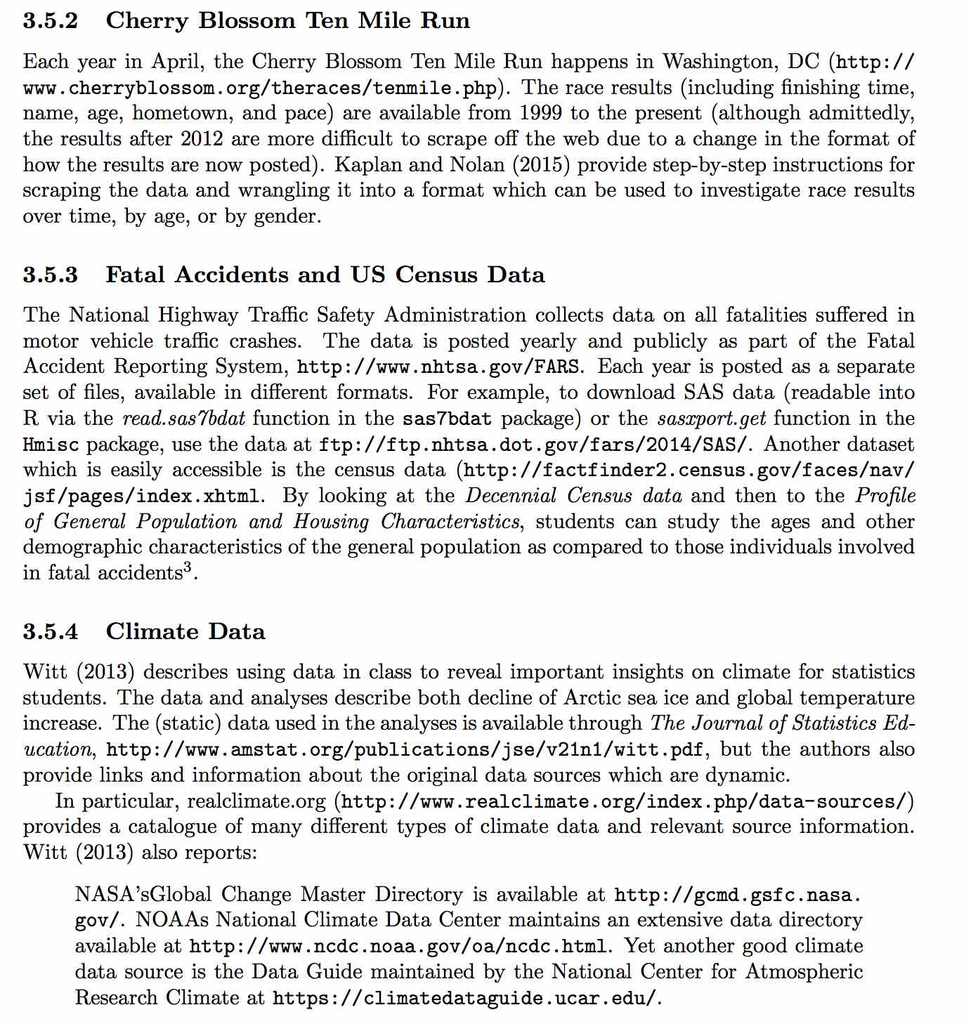

[figure not shown]

# Thank you!

Jo Hardin  
Pomona College  
jo.hardin@pomona.edu  
https://github.com/hardin47/DynamicData  
@jo_hardin47